# Timing information

This report shows the time and memory used to run `derfinder` for single base resolution differential expression analysis. as well as using the `coverageToExon()` function included in the `derfinder` package [requires the output from the *fullCov* step].

# Results

```r
## Extract information from Gmail
system('cp ../../efficiency_analytics/client_secrets .')
system('python ../../efficiency_analytics/analyze_efficiency.py --email fellgernon@gmail.com --folder "Cluster/derSoftware" --outfile timing-derSoftware.txt')
```

```r
## Load libraries
library("ggplot2")
library("knitr")
```

```r
## Setup

## Define number of cores used
exps <- c('brainspan', 'simulation', 'hippo', 'snyder', 'stem')

## Read data and process it
all <- read.table('timing-derSoftware.txt', header = TRUE, stringsAsFactors = FALSE)
all <- all[!grepl('brainspan.*run3', all$jobid), ] # remove older info
all$step <- gsub('.*th', 'TopHat', sapply(strsplit(all$jobid, "-"), function(x) x[1]))
all$memG <- all$memory
all$memG[all$memunit == "M"] <- all$memG[all$memunit == "M"] / 1024
all$chr <- gsub('.*chr', 'chr', all$jobid)
all$chr[ !grepl('chr', all$chr) ] <- NA

## Experiment info
all$experiment <- NA
for(exp in exps) {
    all$experiment[ grepl(exp, tolower(all$jobid)) ] <- exp
}
all$experiment[ all$step %in% c('TopHat', 'bigwig') ] <- 'simulation'
all$experiment[ all$jobid == 'makeBai-Sim' ] <- 'simulation'

## Cores info
all$cores <- mapply(function(chr, exp, step) {
    if(step == 'fullCov') {
        return(10L)
    } else if(step == 'derA') {
        if(exp == 'brainspan') {
            return(ifelse(chr == 'chrY', 2L, ifelse(chr == 'chr1', 40L, ifelse(chr == 'chr2', 32L, ifelse(chr == 'chr3', 27L, ifelse(chr == 'chr19', 29L, 20L))))))
        } else if (exp == 'simulation'){
            return(1L)
        } else if (exp == 'hippo'){
            return(2L)
        } else if (exp == 'snyder'){
            return(4L)
        } else if (exp == 'stem'){
            return(8L)
        }
    } else if(step == 'regMat') {
        return(5L)
    } else if(step == 'TopHat') {
        return(4L)
    } else if(step == 'summOv') {
        return(ifelse(exp == 'hippo', 24L, 10L))
    } else {
        return(1L)
    }
}, all$chr, all$experiment, all$step)
all$timeByCore <- all$walltime * all$cores
all$memByCore <- all$memG / all$cores


## Add software labels
all$software <- factor(ifelse(all$step %in% c('toSam', 'htseq'), 'HTSeq', ifelse(all$step == 'summOv', 'GenomicRanges', ifelse(all$step == 'TopHat', 'TopHat', ifelse(all$step %in% c('makeBai', 'regVsDERs', 'PNAS', 'summInfo'), 'misc', ifelse(all$step == 'derR', 'regionReport', 'derfinder'))))))

## Experiment and cores groups info
all$experiment <- factor(all$experiment, levels = exps)
all$coresGroups <- all$cores
all$coresGroups[ all$cores >= 20] <- '20+'
all$coresGroups <- factor(all$coresGroups, levels = c(1, 2, 4, 5, 8, 10, '20+'))

## Types of analysis
all$analysis <- factor(ifelse(all$step %in% c('derMod', 'derA', 'derM'), 'Single-base DER', ifelse(all$step %in% c('toSam', 'htseq', 'summOv', 'covToEx'), 'Exon count', ifelse(all$step == 'regMat', 'Expressed-region DER', ifelse(all$step == 'fullCov', 'Load data', ifelse(all$step == 'derR', 'HTML report', 'misc'))))))

## Show only information for the data sets described in this website
all <- subset(all, experiment %in% c('brainspan'))
```

## Adjusting by number of cores

The following plots show the wall time and memory used by each job while taking into account the number of cores used by each job. Note that doing so is a crude approximation of how much time and memory each job would have needed had it ran on a single node.

Points are colored by which analysis type they belong to. Note that the loading data step is required for the single base-level and expressed regions-level DER approaches as well as exon counting (with `derfinder`).

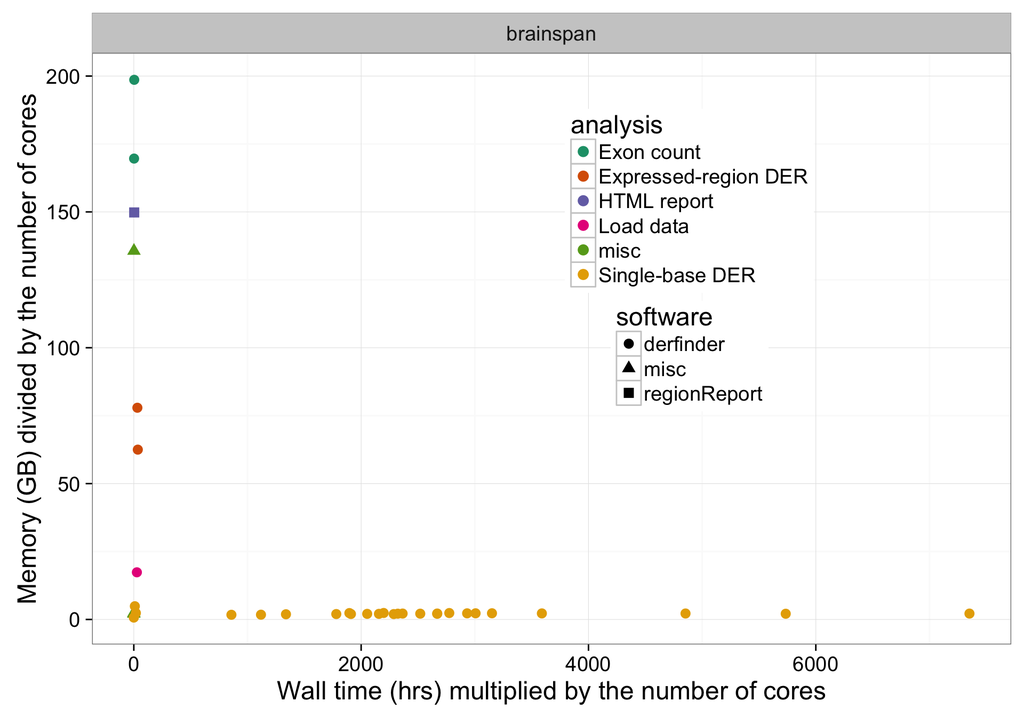

```r
## Walltime and memory adjusted by number of cores (it's an approximation)
ggplot(all, aes(x=timeByCore, y=memByCore, colour=analysis, shape=software)) + geom_point(size = 3) + facet_grid(~ experiment) + xlab("Wall time (hrs) multiplied by the number of cores") + ylab("Memory (GB) divided by the number of cores") + scale_colour_brewer(palette="Dark2") + theme_bw(base_size = 18) + theme(legend.position=c(.65, .65))
```

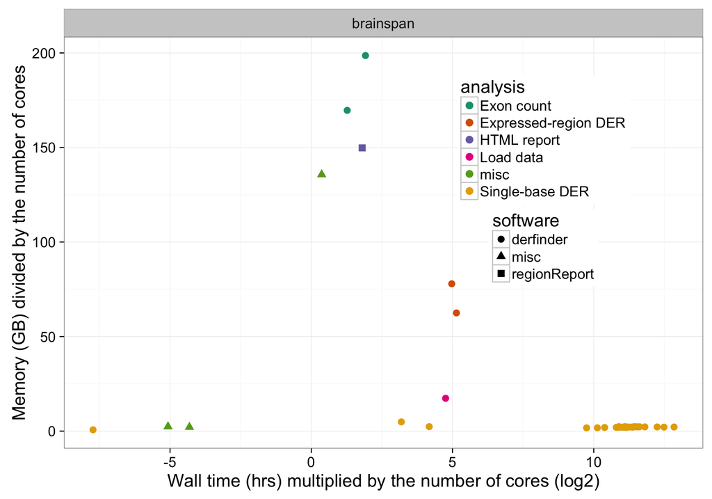

```r
ggplot(all, aes(x=log2(timeByCore), y=memByCore, colour=analysis, shape=software)) + geom_point(size = 3) + facet_grid(~ experiment) + xlab("Wall time (hrs) multiplied by the number of cores (log2)") + ylab("Memory (GB) divided by the number of cores") + scale_colour_brewer(palette="Dark2") + theme_bw(base_size = 18) + theme(legend.position=c(.75, .65))
```

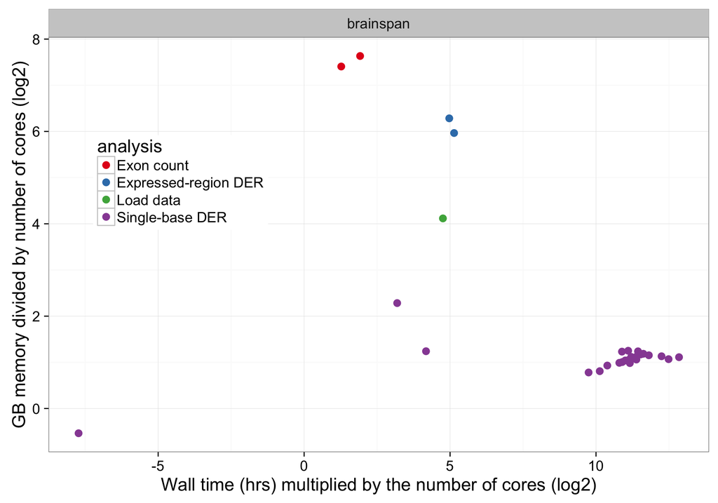

```r
## For supp text
time <- ggplot(subset(all, !software %in% c('TopHat', 'regionReport') & analysis != 'misc'), aes(x=log2(timeByCore), y=log2(memByCore), colour=analysis)) + geom_point(size = 3) + facet_grid(~ experiment) + xlab("Wall time (hrs) multiplied by the number of cores (log2)") + ylab("GB memory divided by number of cores (log2)") + scale_colour_brewer(palette="Set1") + theme_bw(base_size = 18) + theme(legend.position=c(.2, .65))
time
```

```r
pdf(file = 'time.pdf', width = 10)
time
dev.off()
```

```r
#system('open time.pdf')
```

## Resources by step for each analysis

```r
getInfo <- function(df, sumTime = FALSE, peakCores = FALSE) {
    memByCore <- max(df$memByCore)
    walltime <- ifelse(sumTime, sum(df$walltime), max(df$walltime))
    memG <- max(df$memG)
    peakCores <- ifelse(peakCores, max(df$peakCores), sum(df$cores))
    res <- c(memByCore = memByCore, walltime = walltime, memG = memG, peakCores = peakCores)
    return(res)
}

analysisInfo <- list('Single-base DER' = c('Load data', 'Single-base DER'),
    'Expressed-region DER' = c('Load data', 'Expressed-region DER'),
    'HTML report' = 'HTML report',
    'Exon count - derfinder' = 'Load data'
)
analysisInfo <- lapply(analysisInfo, function(x) { which(all$analysis %in% x)})
analysisInfo[[4]] <- c(analysisInfo[[4]], which(all$step == 'covToEx'))
analysisInfo$"Exon count - HTSeq" <- which(all$step %in% c('toSam', 'htseq'))
analysisInfo$"Exon count - GenomicRanges" <- which(all$step == 'summOv')

## Summarize the information for each step of each analysis
analysisSummary <- lapply(names(analysisInfo), function(analysis) {
    current <- all[analysisInfo[[analysis]], ]
    res_analysis <- lapply(exps, function(exp) {
        use <- subset(current, experiment == exp)
        if(nrow(use) == 0) return(NULL)
        res_exp <- lapply(unique(use$step), function(step) {
            res_step <- as.data.frame(t(getInfo(use[use$step == step, ])))
            res_step$step <- step
            res_step$experiment <- exp
            res_step$analysis <- analysis
            return(res_step)
        })
        res_exp <- do.call(rbind, res_exp)
        return(res_exp)
    })
    res_analysis <- do.call(rbind, res_analysis)
    return(res_analysis)
})
analysisSummary <- do.call(rbind, analysisSummary)
```

The table shown below shows per analysis the maximum memory used by a job and maximum wall time for that step. This is assuming that all jobs for a given step ran simultaneously. For example, that all jobs running `derfinder::analyzeChr()` were running at the same time. Note that for some analyses relied on the same steps, like loading the data (*fullCov*). This table can be useful to find the peak number of cores (the sum of cores for all jobs running simultaneously) for a given analysis step.

```r
kable(analysisSummary, format = 'markdown', digits = c(2, 4, 2))
```

| memByCore | walltime | memG | peakCores | step | experiment | analysis |
| --- | --- | --- | --- | --- | --- | --- |
| 4.87 | 9.1136 | 4.87 | 1 | derM | brainspan | Single-base DER |
| 2.38 | 183.7903 | 86.43 | 510 | derA | brainspan | Single-base DER |
| 0.69 | 0.0047 | 0.69 | 1 | derMod | brainspan | Single-base DER |
| 17.35 | 2.7008 | 173.50 | 10 | fullCov | brainspan | Single-base DER |
| 77.92 | 7.0422 | 389.60 | 10 | regMat | brainspan | Expressed-region DER |
| 17.35 | 2.7008 | 173.50 | 10 | fullCov | brainspan | Expressed-region DER |
| 149.80 | 3.4858 | 149.80 | 1 | derR | brainspan | HTML report |
| 17.35 | 2.7008 | 173.50 | 10 | fullCov | brainspan | Exon count - derfinder |
| 198.61 | 3.7794 | 198.61 | 2 | covToEx | brainspan | Exon count - derfinder |

## Resources for each analysis

```r
## Summary the information for each analysis
peaks <- lapply(names(analysisInfo), function(analysis) {
    res_analysis <- lapply(exps, function(exp) {
        current <- analysisSummary[analysisSummary$analysis == analysis & analysisSummary$experiment == exp, ]
        if(nrow(current) == 0) return(NULL)
        res_exp <- as.data.frame(t(getInfo(current, sumTime = TRUE, peakCores = TRUE)))
        res_exp$experiment <- exp
        res_exp$analysis <- analysis
        return(res_exp)
    })
    res_analysis <- do.call(rbind, res_analysis)
    return(res_analysis)
})
peaks <- do.call(rbind, peaks)

save(peaks, file = 'peaks.Rdata')
```

We can further summarize the resources used by each analysis by identified the maximum memory used in the steps required for a particular analysis and the total wall time for running all the steps when all the jobs of a particular step are running simultaneously. Thus giving us the total actual wall time to run a specific analysis and the maximum memory required.

The table below shows the final summary. Note that in some analyses, the peak memory is from the *fullCov* step. We did not focus on reducing the memory load of this step as we sacrificed memory for speed. We know that much lower memory limits can be achieved using 1 core instead of the 10 cores used.

```r
kable(peaks, format = 'markdown', digits = c(2, 3, 2))
```

| memByCore | walltime | memG | peakCores | experiment | analysis |
| --- | --- | --- | --- | --- | --- |
| 17.35 | 195.609 | 173.50 | 510 | brainspan | Single-base DER |
| 77.92 | 9.743 | 389.60 | 10 | brainspan | Expressed-region DER |
| 149.80 | 3.486 | 149.80 | 1 | brainspan | HTML report |
| 198.61 | 6.480 | 198.61 | 10 | brainspan | Exon count - derfinder |

Regarding the high memory load for the HTML report, this could be significantly lowered by only loading the required coverage data used for the plots instead of the full output from the *fullCov* step. That is, using the *which* argument from `fullCoverage()` to create a much smaller *fullCov* object, which would also reduce the memory used when plotting.

**Note**: since these analyses were done, we have found other ways to run `derfinder::regionMatrix()` that require less memory. In particular, if you have BigWig files (as those generated by `Rail-RNA` (Nellore, Collado-Torres, Jaffe, Alquicira-Hernández, et al., 2015)), we recommend using `railMatrix()`.

# Details

The following table shows the details of the resources used by the different jobs. It shows the experiment (*experiment*), the analysis step (*step*), wall time used (shown in hours, *walltime*), number of cores used (*cores*), memory in GB used (*memG*), software used (*software*), analysis for which the step is used (*analysis*), and the job name (*jobib*). Furthermore, it shows two simple approximations:

- *timeByCore* is the wall time (in hours) multiplied by the number of cores used. It is a very simple approximation for the wall time used had the job been ran on a single node. This approximation is known to be false, but it gives a basic idea.
- *memByCore* is the memory (in GB) divided by the number of cores used. It is an approximation for the memory used had the job been ran on a single node.

These are the following analysis steps:

1. **fullCov** Extract coverage information from raw files (BAM or BigWig) by chromosome, then filter it, and save it in Rdata files.
2. **derMod** Calculate the sample depth adjustments and build models appropriate for the experiment.
3. **derA** Run single base-level analysis by chromosome.
4. **derM** Merge derfinder analysis results from the different chromosomes, calculate p-values and q-values.
5. **derR** Generate HTML report with `regionReport`.
6. **regMat** Run expressed regions-level analysis with `regionMatrix()`.
7. **regsVsDers** Compare expressed regions-level vs single base-level approaches for the derfinder software paper.
8. **covToExon** Generate exon table using `derfinder::coverageToExon()` for UCSC hg19 knownGene or GRCh37 p11 Ensembl annotation table.
9. **summInfo** Summarize results to then use then in the derfinder software paper.

```r
library("DT")

## Print whole table
d <- all[, c("experiment", "step", "walltime", "cores", "memG", "timeByCore", "memByCore", "software", "analysis", "jobid")]
datatable(d, options = list(pagingType='full_numbers', pageLength=50, scrollX='100%')) %>% formatRound(columns = c(3, 5:7), digits = 3)
```

|  | experiment | step | walltime | cores | memG | timeByCore | memByCore | software | analysis | jobid |
| --- | --- | --- | --- | --- | --- | --- | --- | --- | --- | --- |
| 1 | brainspan | regVsDERs | 0.0297222222222 | 1 | 2.371 | 0.0297222222222 | 2.371 | misc | misc | regVsDERs-brainspan.run4-v1.0.10 |
| 2 | brainspan | regMat | 6.27805555556 | 5 | 389.6 | 31.3902777778 | 77.92 | derfinder | Expressed-region DER | regMat-brainspan |
| 6 | brainspan | covToEx | 3.77944444444 | 1 | 198.613 | 3.77944444444 | 198.613 | derfinder | Exon count | covToEx-brainspan-ensembl |
| 7 | brainspan | covToEx | 2.415 | 1 | 169.629 | 2.415 | 169.629 | derfinder | Exon count | covToEx-brainspan-ucsc |
| 12 | brainspan | summInfo | 1.29027777778 | 1 | 135.665 | 1.29027777778 | 135.665 | misc | misc | summInfo-brainspan.run4-v1.0.10 |
| 59 | brainspan | derR | 3.48583333333 | 1 | 149.801 | 3.48583333333 | 149.801 | regionReport | HTML report | derR-brainspan.run4-v1.0.10 |
| 60 | brainspan | regVsDERs | 0.0502777777778 | 1 | 2.094 | 0.0502777777778 | 2.094 | misc | misc | regVsDERs-brainspan.run4-v1.0.10 |
| 61 | brainspan | derM | 9.11361111111 | 1 | 4.867 | 9.11361111111 | 4.867 | derfinder | Single-base DER | derM-brainspan.run4-v1.0.10 |
| 62 | brainspan | derA | 183.790277778 | 40 | 86.431 | 7351.61111112 | 2.160775 | derfinder | Single-base DER | derA-brainspan.run4-v1.0.10.chr1 |
| 63 | brainspan | derA | 179.765 | 27 | 59.153 | 4853.655 | 2.19085185185185 | derfinder | Single-base DER | derA-brainspan.run4-v1.0.10.chr3 |

[output cut: 25 more lines]

Table made using `DT` ([Xie, 2015](http://CRAN.R-project.org/package=DT)).

# Reproducibility

Date the report was generated.

```
## [1] "2016-03-21 15:38:25 EDT"
```

Wallclock time spent generating the report.

```
## Time difference of 4.59 secs
```

```
##  setting  value
##  version  R version 3.2.2 (2015-08-14)
##  system   x86_64, darwin13.4.0
##  ui       X11
##  language (EN)
##  collate  en_US.UTF-8
##  tz       America/New_York
##  date     2016-03-21
```

```
## Packages ---------------------------------------------------------------------------------------------------------------
```

```
##  package       * version  date       source
##  bibtex          0.4.0    2014-12-31 CRAN (R 3.2.0)
##  bitops          1.0-6    2013-08-17 CRAN (R 3.2.0)
##  colorspace      1.2-6    2015-03-11 CRAN (R 3.2.0)
##  devtools        1.10.0   2016-01-23 CRAN (R 3.2.3)
##  digest          0.6.9    2016-01-08 CRAN (R 3.2.3)
##  DT            * 0.1      2015-06-09 CRAN (R 3.2.0)
##  evaluate        0.8      2015-09-18 CRAN (R 3.2.0)
##  formatR         1.2.1    2015-09-18 CRAN (R 3.2.0)
##  ggplot2       * 2.0.0    2015-12-18 CRAN (R 3.2.3)
##  gtable          0.1.2    2012-12-05 CRAN (R 3.2.0)
##  highr           0.5.1    2015-09-18 CRAN (R 3.2.0)
##  htmltools       0.3      2015-12-29 CRAN (R 3.2.3)
##  htmlwidgets     0.5      2015-06-21 CRAN (R 3.2.1)
##  httr            1.1.0    2016-01-28 CRAN (R 3.2.3)
##  jsonlite        0.9.19   2015-11-28 CRAN (R 3.2.2)
##  knitcitations * 1.0.7    2015-10-28 CRAN (R 3.2.0)
##  knitr         * 1.12.3   2016-01-22 CRAN (R 3.2.3)
##  labeling        0.3      2014-08-23 CRAN (R 3.2.0)
##  lubridate       1.5.0    2015-12-03 CRAN (R 3.2.3)
##  magrittr        1.5      2014-11-22 CRAN (R 3.2.0)
##  memoise         1.0.0    2016-01-29 CRAN (R 3.2.3)
##  munsell         0.4.3    2016-02-13 CRAN (R 3.2.3)
##  plyr            1.8.3    2015-06-12 CRAN (R 3.2.1)
##  R6              2.1.2    2016-01-26 CRAN (R 3.2.3)
##  RColorBrewer    1.1-2    2014-12-07 CRAN (R 3.2.0)
##  Rcpp            0.12.3   2016-01-10 CRAN (R 3.2.3)
##  RCurl           1.95-4.7 2015-06-30 CRAN (R 3.2.1)
##  RefManageR      0.10.6   2016-02-15 CRAN (R 3.2.3)
##  reshape2        1.4.1    2014-12-06 CRAN (R 3.2.0)
##  RJSONIO         1.3-0    2014-07-28 CRAN (R 3.2.0)
##  rmarkdown     * 0.9.5    2016-02-22 CRAN (R 3.2.3)
##  scales          0.3.0    2015-08-25 CRAN (R 3.2.0)
##  stringi         1.0-1    2015-10-22 CRAN (R 3.2.0)
##  stringr         1.0.0    2015-04-30 CRAN (R 3.2.0)
##  XML             3.98-1.3 2015-06-30 CRAN (R 3.2.0)
##  yaml            2.1.13   2014-06-12 CRAN (R 3.2.0)
```

# Bibliography

This report was generated using `rmarkdown` ([Allaire, Cheng, Xie, McPherson, et al., 2016](http://CRAN.R-project.org/package=rmarkdown)) with `knitr` ([Xie, 2014](http://www.crcpress.com/product/isbn/9781466561595)) running behind the scenes. Timing information extracted from the SGE reports using `efficiency analytics` ([Frazee, 2014](http://dx.doi.org/10.6084/m9.figshare.878000)). Figures and citations were made using `ggplot2` ([Wickham, 2009](http://had.co.nz/ggplot2/book)) and `knitcitations` ([Boettiger, 2015](http://CRAN.R-project.org/package=knitcitations)) respectively.

Citation file: timing.bib

[1] J. Allaire, J. Cheng, Y. Xie, J. McPherson, et al. *rmarkdown: Dynamic Documents for R*. R package version 0.9.5. 2016. URL: http://CRAN.R-project.org/package=rmarkdown.

[2] C. Boettiger. *knitcitations: Citations for ‘Knitr’ Markdown Files*. R package version 1.0.7. 2015. URL: http://CRAN.R-project.org/package=knitcitations.

[3] A. Frazee. *Efficiency analysis of Sun Grid Engine batch jobs*. 2014. URL: http://dx.doi.org/10.6084/m9.figshare.878000.

[4] A. Nellore, L. Collado-Torres, A. E. Jaffe, J. Alquicira-Hernández, et al. “Rail-RNA: Scalable analysis of RNA-seq splicing and coverage”. In: *bioRxiv* (2015).

[5] H. Wickham. *ggplot2: Elegant Graphics for Data Analysis*. Springer-Verlag New York, 2009. ISBN: 978-0-387-98140-6. URL: http://had.co.nz/ggplot2/book.

[6] Y. Xie. *DT: A Wrapper of the JavaScript Library ‘DataTables’*. R package version 0.1. 2015. URL: http://CRAN.R-project.org/package=DT.

[7] Y. Xie. “knitr: A Comprehensive Tool for Reproducible Research in R”. In: *Implementing Reproducible Computational Research*. Ed. by V. Stodden, F. Leisch and R. D. Peng. ISBN 978-1466561595. Chapman and Hall/CRC, 2014. URL: http://www.crcpress.com/product/isbn/9781466561595.